# Análisis de Producción de bioetanol a base de maíz y caña de azucar en Argentina

Estefany Herrera Martinez

8 de Sep 2023

## Descripción.

Se eligió un dataset que contiene información del volumen producido de bioetanol (en metros cúbicos) a base de maíz y caña de azucar para la producción de biocombustible, registrados en Argentina durante los años 2017, 2018 y 2019;cabe resaltar que para el año 2019 tiene información de los primeros 5 meses. Se descargó el dataset de la página de datos públicos https://datos.gob.ar (precisamente, en [este link](https://datos.gob.ar/dataset/agroindustria-biocombustible---produccion-por-insumo-bioetanol)) el 8 de Septiembre de 2022. El archivo descargado (`Trabajo Práctico`) contiene el dataset `produccion-de-bioetanol-por-insumo-.csv` que ahora se encuentra en la carpeta `datos` y los gráficos de este trabajo estan guardados en la carpeta output.

El objetivo de este trabajo, es realizar dos visualizaciones del dataset elegido y visualizar cuál insumo produce mayor cantidad de bioetanol.

## Importar los datos.

se importa el dataset de la carpeta datos y se toman las variables relevantes para el análisis : año, mes, producción de bioetanol. Se usa del paquete *introdataviz* la función *stack* que genera una variable de producción de bioetanol y otra variable que clasifica por el tipo de insumo, a esta función se le agrega las variables de los meses y años con la función *cbind* obteniendo un dataset que tiene 4 variables ( mes, año, producción y tipo de insumo).Para que el dataset quede prolijo,se les cambia los nombres a las variables por lo que corresponde: “Mes”, “Año”, “Producción” e “Insumo”.

|  | Año | Mes | Produccion | Insumo |
| --- | --- | --- | --- | --- |
| 1 | 2017 | Enero | 37794 | caña |
| 2 | 2017 | Febrero | 35607 | caña |
| 3 | 2017 | Marzo | 38696 | caña |
| 4 | 2017 | Abril | 35355 | caña |
| 5 | 2017 | Mayo | 44053 | caña |
| 6 | 2017 | Junio | 51159 | caña |

## Producción de bioetanol por insumo.

Se desea observar por medio de gráficos la producción de bioetanol según el tipo de materia prima , por lo tanto, se utiliza la libreria de ggplot2 para su elaboración.

### Código

```r
altura<- .1

 g1<-ggplot(Bioetanol,
       aes(x ="" ,
           y = Produccion,
           fill = Insumo)) +
  # para dibujar la distirbucion
  introdataviz::geom_flat_violin(trim=FALSE,
                                 alpha = 0.4,
                                 position = position_nudge(x = altura+.05)) +
  # dibujar ne forma dee punto las observaciones
  geom_point(aes(colour = Insumo),
             size = 2,
             alpha = .5,
             show.legend = FALSE,
             position = position_jitter(width = altura,
                                        height = 0)) +
  # hacer los boxplot de las observaciones
  geom_boxplot(aes(group=Insumo, color=Insumo),
               width = altura,
               alpha = 0.4,
               show.legend = FALSE,
               outlier.shape = NA,
               position = position_nudge(x = -altura*2)) +

   # poner nombre y limites en el eje y
  scale_y_continuous(name = "Producción de bioetanol en m³",
                     breaks = seq(0, 80000, 20000),
                     limits = c(0, 80000)) +
   # Girar  el eje
  coord_flip() +

   # eliminar el nombre de  xlim del grafico
   scale_x_discrete(labels = NULL, breaks = NULL) +

   # colocar bonito el gráfico
  labs(x="",title = "Maíz vs Caña de azucar",
       subtitle = "Producción de bioetanol por tipo de insumo",
       caption = "fecha: 9 Sep 2022" ) +
   # escoger forma del plano
  theme_minimal() +

  theme(panel.grid.major.y = element_blank(),
        legend.background = element_rect(fill = "white", color = "white"))
```

### Output

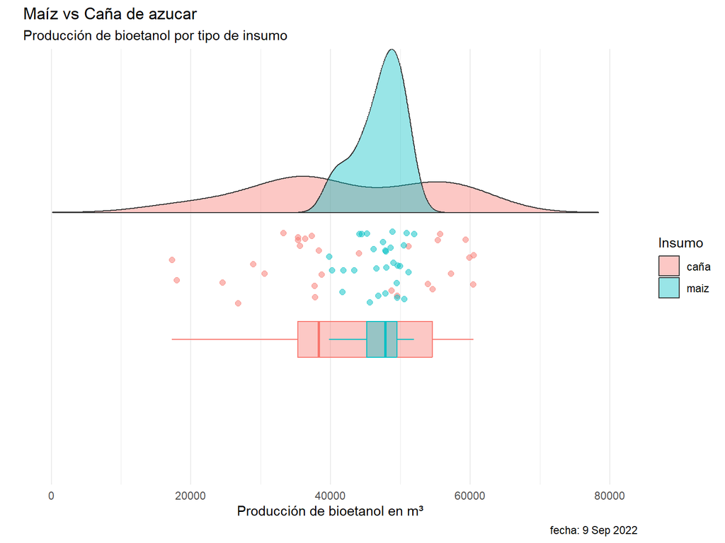

Se puede observar que hay mayor producción de bioetanol a base me maíz.

Ahora veamos un gráfico que divida la producción de bioetanol por años.

## Producción de bioetanol a base de materia prima por año .

### Código

```r
# se realizó nos mismos pasos que en codigo anterior.
altura<- .1

g2<-ggplot(Bioetanol,
       aes(x ="" ,
           y = Produccion,
           fill = Insumo)) +

  introdataviz::geom_flat_violin(trim=FALSE,
                                 alpha = 0.4,
                                 position = position_nudge(x = altura+.05)) +

  geom_point(aes(colour = Insumo),
             size = 2,
             alpha = .5,
             show.legend = FALSE,
             position = position_jitter(width = altura, height = 0)) +

  geom_boxplot(aes(group=Insumo, color=Insumo),
               width = altura,
               alpha = 0.4,
               show.legend = FALSE,
               outlier.shape = NA,
               position = position_nudge(x = -altura*2)) +

  scale_y_continuous(name = "Producción de bioetanol en m³",
                     breaks = seq(0, 80000, 20000),
                     limits = c(0, 80000)) +
  coord_flip() +
  facet_wrap(~factor(Año)) +

  scale_x_discrete(labels = NULL, breaks = NULL) +

  labs(x="", title = "Maíz vs Caña de azucar",
       subtitle = "Producción de bioetanol por tipo de insumo en los años 2017,2018 y 2019",
       caption = "fecha: 9 Sep 2022") +
  theme_minimal() +

  theme(panel.grid.major.y = element_blank(),
       # legend.position = "bottom" ,
        legend.background = element_rect(fill = "white", color = "white"))
```

### Output

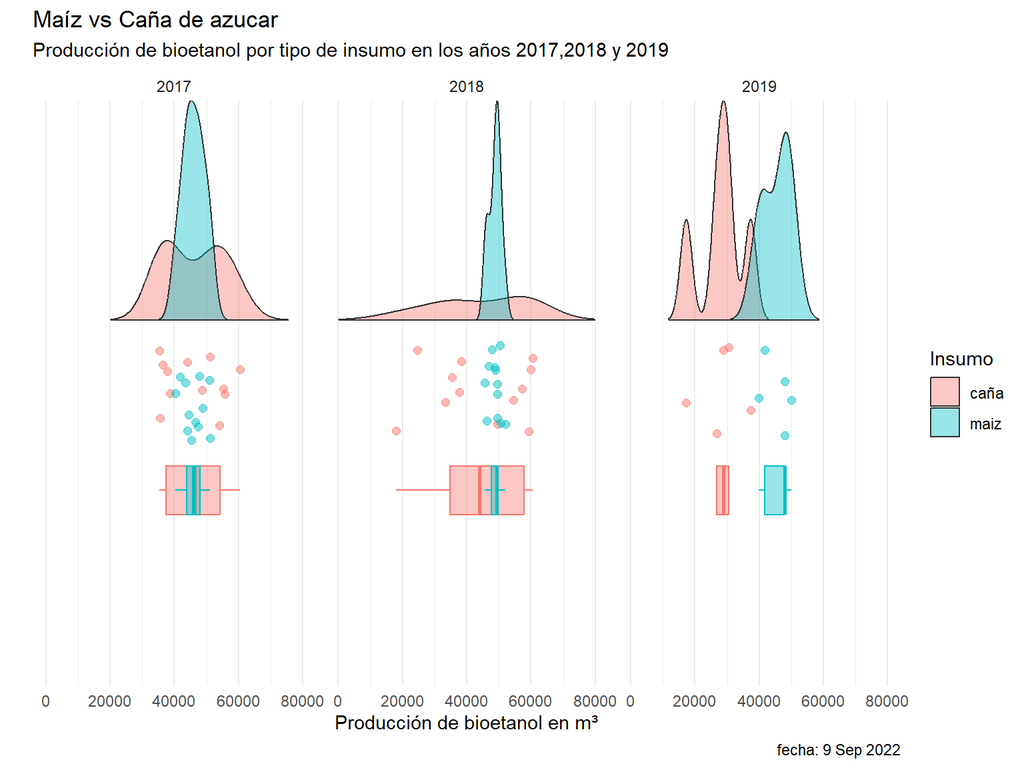

Se puede observar en los gráficos de manera general, que la producción de bioetanol a base de maíz es menos dispersa en relación a la producción de bioetanol a base de caña de azucar.

En el segundo gráfico muestra que el producción de bioetanol a base de maíz fue mayor en lo años 2018 y 2019, mientras que en el 2017 fue muy similiar la producción de bioetanol entre los insumos.

## producción de bioetanol por insumo en los diferetes meses de los años.

Ahora realizamos el gráfico para observar la producción de bioetanol por insumo por mes de cada año, para esto utlizo la libreria de *ggplot2*.

### Código

```r
require(tidyverse)

# convierto en factor el mes y escribo los meses ordinalmente para
# que en el grafico aparezcan en orden.

Bioetanol$Mes<-factor(Bioetanol$Mes,
               levels = c("Enero","Febrero","Marzo","Abril","Mayo",
                            "Junio","Julio","Agosto","Septiembre",
                            "Octubre","Noviembre","Diciembre"))

# convierto en factor la variable año
Bioetanol$Año<-as.factor(Bioetanol$Año)

# grafico la produccion de insumos por año

library(ggplot2)

g3<-ggplot(data=Bioetanol,
       aes(x=factor(Mes),
           y=Produccion,
           group=Insumo,
           shape=Insumo,
           color=Insumo,
           x)) +
  geom_line() +
  geom_point() +
  facet_grid( .~Año, switch = "x") +  #scales="free", space="free"
  #scale_x_discrete("Mes") +
  #scale_y_continuous("Producción") +
  theme(axis.text.x = element_text(angle = 90))+
  labs(x="Mes", y="Producción de bioetanol en m³", title = "Maíz vs Caña de azucar",
       subtitle = "Producción de bioetanol a base de maiz y caña de azucar",
       caption = "fecha: 9 Sep 2022")
```

### Output

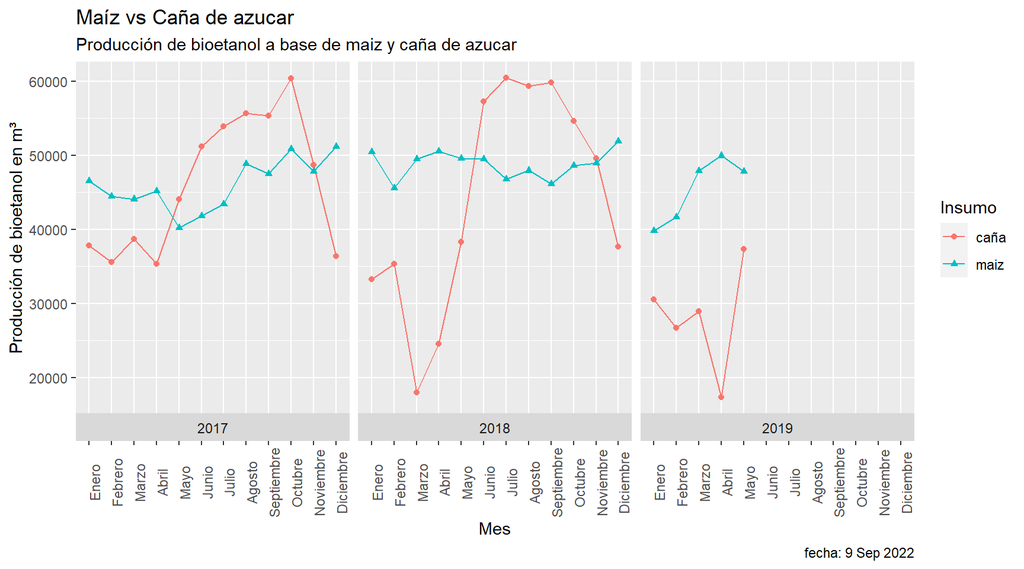

En el gráfico podemos ver que la producción de bioetanol a base de maíz tiende a aumentar en los últimos meses de cada año, caso contrario con la producción a base de caña de azucar. Además, se observa que la producción a base de maíz, tiene menos variabilidad con respecto a la pruducción a base de caña de azucar.

Para maíz, la máxima producción de bioetanol en el año 2017 se desarrollo en los meses de diciembre y la mínima en el mes de mayo, para el año 2018, la máxima se ubicó en el mes de diciembre y la mínima en el mes de febrero,por último para el año 2019,abril fue el mes con mayor producción de bioetanol con respecto a los 5 primeros meses y enero, el mes con menor prodicción.

Para caña de azucar, el mes con mayor producción de bioetanol en el año 2017, se ubicó en el mes de octubre y la menor producción en el mes de abril,para el año 2018, la maxima producción de bioetanol fue en el mes de julio y la mínima en el mes de marzo, por último, mayo, fue el mes con máxima producción de bioetanol para el 2019 y abril, el mes con menor producción de bioetanol, cabe resaltar que en el 2019 solo se tiene los datos de producción de bioetanol de los primeros 5 meses.

## Referencias.

Página para gráficos ([https://r-graph-gallery.com/index.html])

Análisis de Temperatura([file:///C:/Users/Usuario/AppData/Local/Temp/Rar$EXa0.115/datos_temperatura/analisis.html])